# Data preparation phase

In this phase, we are going to transform the data, by applying the z-normalization and the z-log normalization. We are also going to prepare the data for cross validation which will be used in the different classification algorithm files.

# 0. Import Library

```r
library("readxl")
library(referenceIntervals)
library(dplyr)
library(caTools) # to split the dataset into training set and test set
source("./tools/data_preparation_functions.R")
```

# 1. Dataset : Raisin

```r
data <- read_excel("./dataset/Raisin_Dataset/Raisin_Dataset.xlsx")
data$Class = as.factor(data$Class)
```

# 2. Splitting data into train and test data

```r
sample_data = sample.split(data$Class, SplitRatio = 2/3)
train_data <- subset(data, sample_data == TRUE)
test_data <- subset(data, sample_data == FALSE)
```

```r
# count number of each Class in each dataset
table(train_data$Class)
```

```
##
##   Besni Kecimen
##     300     300
```

```r
table(test_data$Class)
```

```
##
##   Besni Kecimen
##     150     150
```

We have the same proportion of Kecimen and Besni in both dataset as the initial dataset.

# 3. Example of Reference limit

As mentioned before, our reference individuals will be the Kecimen variety

```r
reference_individuals <- train_data[train_data$Class == "Kecimen",]
```

We just do an example of calculating the reference limit for the Area attribute, but of course we will have to do this for the other attributes.

Example of calculating the Reference limit for the Area :

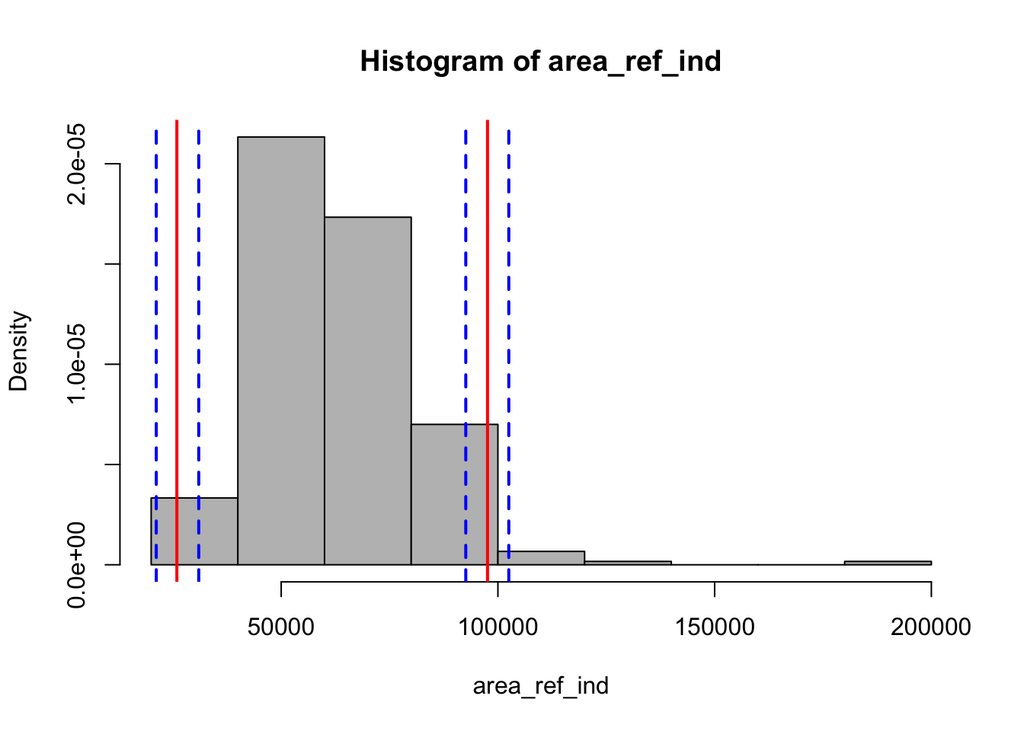

```r
area_ref_ind <- reference_individuals$Area

ri_area <- ref_intervals(reference_individuals, "Area") # method from data_preparation_functions.R file
hist(area_ref_ind, probability = T, col = 'grey')
abline(v=ri_area$Ref_Int, col = 'red', lwd = 2)
abline(v=ri_area$Conf_Int, col = 'blue', lty = 'dashed', lwd = 2)
```

# 4. Z and Z-log transformation

Z-transformation (also called standardization or auto-scaling or normalization)

```r
attribute_list <- list("Area",
                    "MajorAxisLength",
                    "MinorAxisLength",
                    "Eccentricity",
                    "ConvexArea",
                    "Extent",
                    "Perimeter")
```

Here we apply the z-normalization and the z-log normalization to the train data and the test data. For this we calculate the lower_interval and the upper_interval from the reference_individuals (reference_individuals contains only data from the train data). And we use them for the normalization for the train data but also for the test data.

Note: We are not supposed to know the test data, but we also have to normalize them this is why we normalize them with the lower_interval and upper_interval computed with the train data.

See the file data_preparation_functions.R for more information.

```r
result <- z_transform_and_zlog_transform(train_data, test_data, attribute_list, reference_individuals) # see methods from data_preparation_functions.R file
train_data <- result$train_data
test_data <- result$test_data
```

```r
# We just reorder the attributes, by putting the class attribute and the end

train_data <- train_data[,order(colnames(train_data))]
train_data <- train_data %>% relocate(Class, .after = last_col())

test_data <- test_data[,order(colnames(test_data))]
test_data <- test_data %>% relocate(Class, .after = last_col())
```

## Writting data

We write the train data and test data in 2 separated files so that we can use them in different classification algorithms and also it will be easier to compare the classification algorithms.

```r
write.csv2(train_data, file="./dataset/data_transformed/Raisin_transformed_train_data.csv", row.names = FALSE)
write.csv2(test_data, file="./dataset/data_transformed/Raisin_transformed_test_data.csv", row.names = FALSE)
```

# 5. Preparation of another dataset for cross validation

```r
set.seed(123) # so that we have the same sequence each time
```

```r
data <- rbind(train_data, test_data)
kecimen <- data[data$Class == "Kecimen",]
besni <- data[data$Class == "Besni",]
```

```r
kecimen <- prepare_data_for_cross_validation(kecimen) # method from the data_preparation_functions.R file
besni <- prepare_data_for_cross_validation(besni)
```

```r
# we check if our k-folds have the same size
summary(kecimen$k)
```

```
##  1  2  3  4  5  6  7  8  9 10
## 45 45 45 45 45 45 45 45 45 45
```

```r
summary(besni$k)
```

```
##  1  2  3  4  5  6  7  8  9 10
## 45 45 45 45 45 45 45 45 45 45
```

```r
data <- rbind(kecimen, besni)
write.csv2(data, file="./dataset/data_transformed/data_for_cross_validation.csv", row.names = FALSE)
```